# Final Project: Exploring Oil Trade Networks

Author

Baxter Lowell

```r
# read in data (both USA and global oil exports)

library(tidyverse)
library(readr)
library(dplyr)

global_exports_oil <- read.csv(here::here("data/global_oil_exports.csv"), row.names = NULL)

usa_exports <- read.csv(here::here("data/trade_data.csv"), row.names = NULL)

# cleaning up USA oil exports data

usa_exports_clean = usa_exports %>%
  select(c("reporterISO","reporterDesc", "partnerDesc", "partnerISO", "cmdDesc", "altQty", "fobvalue")) %>%
  rename(
    "Exporter" = "reporterISO",
    "Importer" = "partnerISO",
    "Product" = "cmdDesc",
    "quantity_bbl" = "altQty",
    "value_usd" = "fobvalue"
  )%>%
  mutate(
    partnerDesc = recode(partnerDesc,
                     "Korea" = "Rep. of Korea"
                     )
  )


global_exports_clean = global_exports_oil %>%
   select(c("reporterISO", "partnerISO", "reporterDesc", "partnerDesc", "cmdDesc", "altQty", "fobvalue")) %>%
  rename(
    "Exporter" = "reporterISO",
    "Importer" = "partnerISO",
    "Product" = "cmdDesc",
    "quantity_bbl" = "altQty",
    "value_usd" = "fobvalue"
  )%>%
  mutate(
    partnerDesc = recode(partnerDesc,
                     "Korea" = "Rep. of Korea"
                     )
  )%>%
   slice(-560)
```

# Abstract:

For my project, I am using data from 2023 (the most recent public data) from the UN Comtrade database, which is a comprehensive database that tracks global trade data. It is used by organizations such as the World Bank to help track global trade trends. With this data I was able to find some of the major US trading partners, see if oil exportation has any relationship to a quality of life measurement, and view trading networks for individual countries.

# Final Project Introduction: Exploring Global Oil Trade

For my final project, I will be exploring exports of crude oil from different nations around the world. Oil trade is constantly brought up both in economic, political and military contexts, especially given the strain on global oil trade due to the current conflict in Iran and the uncertainty surrounding the Straight of Hormuz. Crude oil is widely considered the most valuable commodity on earth, and is used to provide energy for transportation systems and is a key ingredient in plastics, pharmaceuticals, and other synthetic material production. I thought it would be interesting to explore who trades with who - and how much, to help understand how disruptions may affect different countries based on their export/import statistics.

Some questions I look to answer include: With whom does the USA export the most oil to? Which countries are most reliant on outside sources for oil? Do high export/importers see a better quality of life?

I also aim to create a shiny app that uses the database to give users a way to explore who trades with who. By creating an interactive model, I want users to be able to use my app to help answer their own questions, whether they are driven by economic, political, or strategic interests.

# First Graph: Who does the United States export oil to?

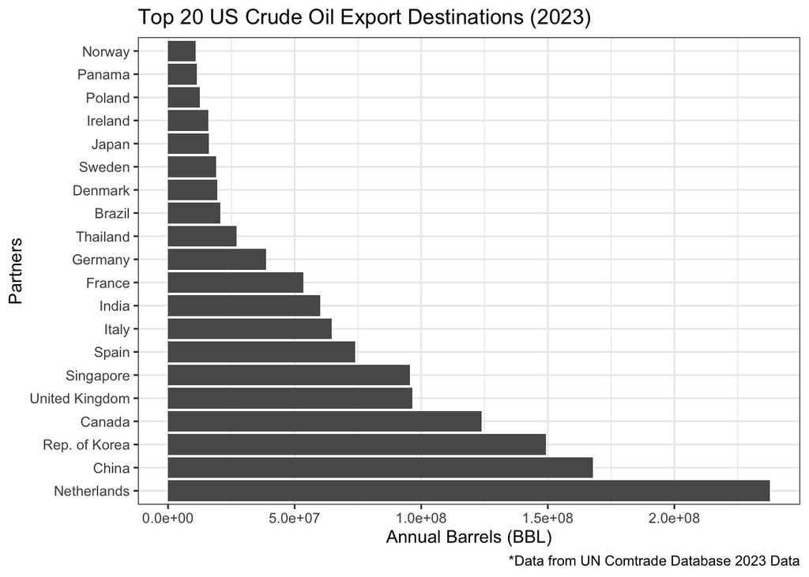

```r
usa_exports_clean %>%
  filter(Importer != "W00") %>%
  filter(partnerDesc != "Other Asia, nes")%>%
  arrange(desc(quantity_bbl))%>%
  slice_head(n = 20)%>%
  mutate(
    partnerDesc = fct_reorder(partnerDesc, quantity_bbl, .desc = TRUE))%>%

ggplot(data = ., aes(x = partnerDesc, y = quantity_bbl))+
  geom_col()+
  labs(title = "Top 20 US Crude Oil Export Destinations (2023)",
       x = "Partners",
       y = "Annual Barrels (BBL)",
       caption = "*Data from UN Comtrade Database 2023 Data"
       )+
  theme_bw()+
  coord_flip()
```

According to the 2023 UN Comtrade Data, the United States, who has lead the world in crude oil production for the past several years, imported the most crude oil to the Netherlands. The Netherlands acts as the gateway for oil imports for the EU. As Europe continues to move away from sanctioned Russian oil, I wonder if they will continue to rely on US oil, or even other sources.

Another data point I found interesting was Canada. Canada has the third most oil reserves on the planet, so I was curious as to why the United States exports so much crude to Canada. Despite their vast reserves, Canada does not produce as much oil as many other countries, and it can be more cost effective for US companies to export oil to Canadian refineries than to ship them across the US to be refined, which explains the high exports found in the data.

# Second Graph: Since oil is considered a key economic resource that is highly valued, I want to see if there is a clear correlation to the amount of oil exported from a country and it’s life expectancy. I also wanted to color the points by region, to see what regions of the world most rely on imported oil.

```r
library(fuzzyjoin)
library(plotly)
hpi_df <- read_csv("https://raw.githubusercontent.com/highamm/ds234_quarto/main/data_online/hpi-tidy.csv")
global_export_region <- stringdist_full_join(
  hpi_df,
  global_exports_clean,
  by = c("Country" = "reporterDesc"),
  max_dist = 2
)
# graph 2: Relating oil exports to life expectancy

global_export_region1 <- global_export_region %>%
  filter(Importer == "W00")%>%
  filter(quantity_bbl > 0)

region_plot <- ggplot(data = global_export_region1, aes(x = LifeExpectancy, y = quantity_bbl, color = Region, label = Country))+
  geom_point()+
  theme_bw()+
  scale_color_viridis_d()+
  labs(title = "Life Expectancy Based on Crude Oil Exports",
       x = " Life Expectancy",
       y = "Barrels Exported",
       caption = "*data from 2023 UN Comtrade Data & Happy Planet Index")

ggplotly(p = region_plot, tooltip = "label")
```

[interactive chart not shown]

This is an interactive graph that shows Life Expectancy (from the Happy Planet Index dataset) vs quantity of oil exported in 2023. My goal of this visual was to explore if countries life expectancy correlated to how much oil they exported, thinking that the money from the sales of oil might contribute to a prosperous economy, which may lead to a higher quality of life, hence a higher life expectancy. I also colored the points by region, to try and show if there were certain patterns by region to show who if there are any outliers by region.

While there is no clear correlation from this graph that exporting oil significantly relates to a country’s life expectancy, there are a couple interesting points to note. For one, Kuwait leads the world in exports, and also seemingly enjoys a relatively high life expectancy. In another instance, two countries that are in similar areas of the world, Kazakhstan and Azerbaijan, have drastically different amounts of exports, yet share similar life expectancy numbers. I think it is safe to conclude that life expectancy cannot be explained by simply one variable, and there are likely many other factors that contribute to it.

# Shiny App: Network Graphs to Explain Trading Partnerships

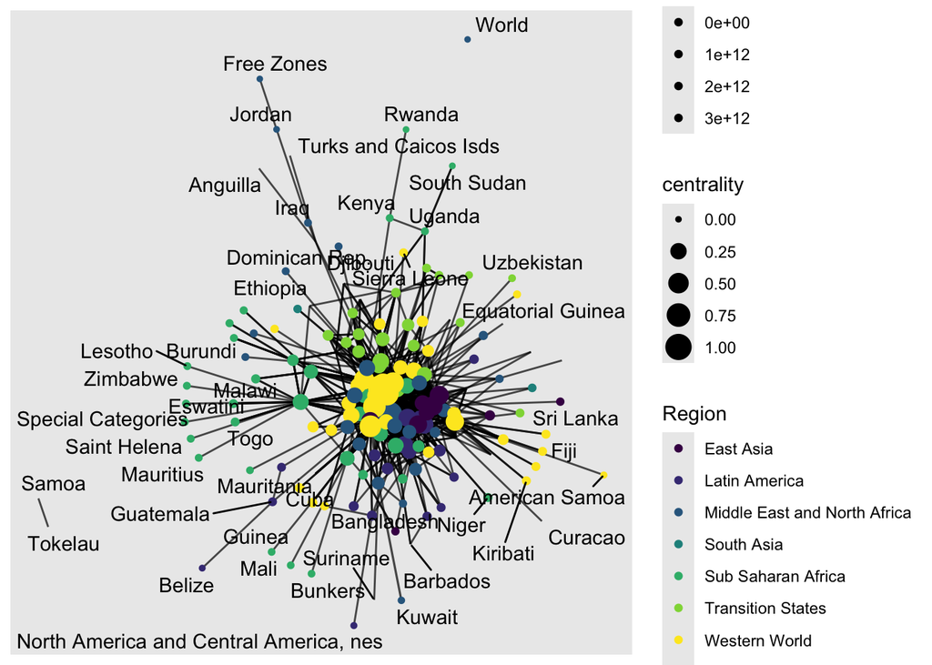

```r
library(rvest)
library(tidygraph)
library(ggraph)


network_graph_data <- global_export_region %>%
  rename(
    from = reporterDesc,
    to = partnerDesc,
    barrels = quantity_bbl
  )
nodes <- network_graph_data %>%
  select(name = from, Region, GovernanceRank, GDPcapita, Population) %>%
  bind_rows(
    network_graph_data %>%
      select(name = to, Region, GovernanceRank, GDPcapita, Population)
  ) %>%
  filter(!is.na(name)) %>%
  distinct(name, .keep_all = TRUE)

valid_nodes <- nodes$name

edges <- network_graph_data %>%
  select(from, to, barrels) %>%
  filter(!is.na(from), !is.na(to), to != "World")

# the following came from Claude, with the prompt : why am I getting an error in my edgelist saying there are NA's present, when I have checked for NA values?

edges <- edges %>%
  filter(from %in% valid_nodes & to %in% valid_nodes)

# End of Claude code

network_obj <- tbl_graph(nodes = nodes, edges = edges, directed = FALSE)

library(ggraph)
ggraph(network_obj |> mutate(centrality = centrality_authority()),
                            layout = "fr") +
  geom_edge_link(aes(width = barrels), alpha = 0.7, show.legend = FALSE) +
  geom_node_point(aes(colour = Region,
                      size = centrality), show.legend = TRUE) +
  scale_edge_width(range = c(0.5, 3)) +
  geom_node_text(aes(label = name), repel = TRUE)+
  scale_colour_viridis_d()
```

While this graph does show oil trade networks, it’s extremely messy. I want to fix it so that the user can select a country, and see the trade network for that individual country. My goal is that this can be used as a tool to predict who is affected the most by any global issue that affects oil trade or production.

# Shiny App

```
Listening on http://127.0.0.1:7605
```

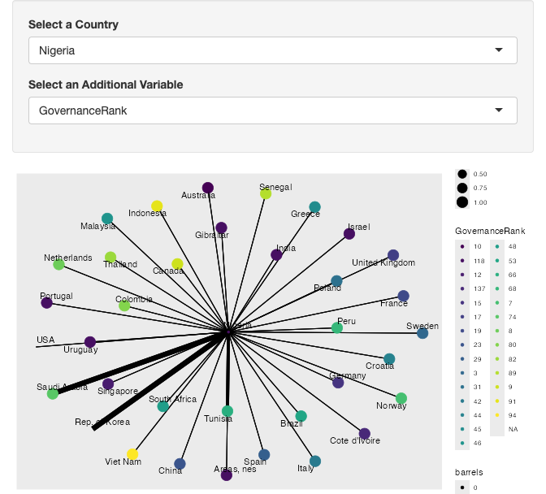

```r
library(shiny)
country_choices <- unique(nodes$name)

ui <- fluidPage(
  sidebarLayout(
  sidebarPanel(
    selectInput("country_select", label = "Select a Country", choices = country_choices),
    selectInput("color_select", label = "Select an Additional Variable", choices =
                  c("GovernanceRank", "Region"))
),

mainPanel(
          plotOutput("network_plot")
          )

)
)

server <- function(input, output, session) {


    output$network_plot <- renderPlot({

edges_filtered <- edges %>%
  filter(from %in% valid_nodes & to %in% valid_nodes) %>%
  filter(from == input$country_select)

nodes_filtered <- nodes %>%
  filter(name %in% c(edges_filtered$from, edges_filtered$to))%>%
  mutate(
    Population = as.numeric(Population),
    GDPcapita = as.numeric(GDPcapita)
  )

network_obj <- tbl_graph(nodes = nodes_filtered, edges = edges_filtered, directed = FALSE)

    ggraph(network_obj |> mutate(centrality = centrality_authority()),
                            layout = "fr") +
  geom_edge_link(aes(width = barrels), alpha = 0.7, show.legend = FALSE) +
  geom_node_point(aes(color = .data[[input$color_select]],
                      size = centrality), show.legend = TRUE) +
  scale_edge_width(range = c(0.5, 3)) +
  geom_node_text(aes(label = name), repel = TRUE)+
  scale_colour_viridis_d()
  })
      }

shinyApp(ui, server)
```

My goal with this app was to create a tool that makes it easy for users to analyze trade markets. This could have been done with any other product, and could have been done in different ways using data over time while controlling for a single country, or even looking at regional trade networks.

# Future Work:

If time was not a constraint for me, I would have liked to look at trade networks over time, maybe while controlling for a select few countries. I’d like to see how different key players in oil trade have changed with whom they trade with over time, and try and explore why those changes may have occured.

Some limitations for me during this project included my data. It was tough for me to clean my data in a way that made it easy to work with, and it was even harder to join my dataset with another while still keeping relevant variables. I wish I knew a little bit more about cleaning and joining datasets, as that would make it easier for me to continue to incorporate additional data sets to look at even more variables that could enhance my analysis.

# AI Appendix:

Prompt I gave Claude: “Why am I getting an error that says I have na’s in my edgelist, even though my to and from columns contain no na values?”

Code I used to fix the problem:

```r
valid_nodes <- nodes$name

edges <- edges %>%
  filter(from %in% valid_nodes & to %in% valid_nodes)
```